# RanCh: A package for abstract discrete *Ran*dom *Ch*oice analysis

William McCausland

2019-08-01

## Introduction

This package provides tools for a research project whose purpose is to help us better understand the foundations of stochastic discrete choice. It includes datasets compiled from the context effects literature, the stochastic intransitivity literature, and from some recent experiments where we observe choices from all doubleton and larger subsets of some universe of objects. It provides graphical tools illustrating likelihood function and posterior density contours, as well as regions, in the space of choice probabilities, defined by various stochastic choice axioms, context effects and other conditions. Finally, it provides tools for parametric and non-parametric inference subject to various combinations of discrete choice axioms, as well as the testing of said axioms.

## Data sets

We provide some datasets from the context effects literature, the stochastic intransitivity literature and from some recent experiments. The data sets are organized in similar ways, allowing for the use of a common set of analytical tools, described below.

### Data sets from the context effects literature

One of the data sets in this package is the choice count data from the experiments described in Amos Tversky (1972), which introduces the similarity effect. The $3 \times 8 \times 7 \times 3$ array `T_1972_counts` contains the data for the three choice domains (“Dots”, “Gambles” and “Applicants”) and eight subjects of that experiment. The first dimension of the array is indexed by choice domain, either as an integer from one to three, or as one of the strings “Dots”, “Gambles” or “Applicants”. The second dimension is indexed by subject identifier, an integer from one to eight. The third dimension is indexed by choice set and the fourth by choice object.

Here and in many other contexts, choice sets and choice objects each have different kinds of indices. In this dataset, the object names are $x$, $y$ and $z$, as in the paper; they can be indexed using the strings `"x"`, `"y"` and `"z"` or the integers 1, 2, and 3, respectively. Choice sets, subsets of the choice universe $\{x,y,z\}$, can be indexed using the strings `"x"`, `"y"`, `"xy"`, …, `"xyz"` or by integers we will call set indices. Each digit (or bit) in the binary representation of a set index in an inclusion indicator: object $i \in \{1,\ldots,3\}$ is in the set if and only if the $i$’th digit from the right is 1. For example, the sets $\{x,z\}$, $\{y,z\}$ and $\{x,y,z\}$ have indices that are binary 101, 110 and 111, or decimal 5, 6 and 7. This convention for indexing sets has some important computational advantages. The singleton set with object $i$ is represented as $2^i−1$. The bitwise “or” of the indices of two sets gives the index of their union; the bitwise “and”, the index of their intersection.

Thus the number of times subject five chose object $x$ from choice set $\{x,y,z\}$ of domain `Dots` is `T_1972_counts["Dots", 5, "xyz", "x"]` or `T_1972_counts[1, 5, 7, 1]`; names and integer indices can be mixed. Counts of impossible events, such as choosing $x$ from $\{y,z\}$ have the value `NA` rather than zero. This is deliberate; accessing information that doesn’t make sense should lead to an immediate (thus relatively easy to find) error.

Here is a cross section of counts for the “Gambles” domain and the first subject, showing the choice sets (the only choice sets used in the experimental design) $\{x,z\}$, $\{y,z\}$ and $\{x,y,z\}$. For example, the number of times this subject chose gamble $x$ when presented with a choice from $\{x,y,z\}$ is 2.

```r
print(T_1972_counts['Gambles', 1, c('xz', 'yz', 'xyz'), ], na.print='-')
        Object
  Subset x  y  z
     xz  7  - 13
     yz  - 10 10
     xyz 2 13 15
```

### Data sets from the stochastic intransitivity literature

Another data set in the package is the count data from the experiment described in Regenwetter, Dana, and Davis-Stober (2011). The $3 \times 18 \times 31 \times 5$ `RDS_2011_counts` contains the data for the three choice domains (“Cash 1”, “Cash 2” and “Noncash”) and 18 subjects of that experiment. The data is organized in a similar way to that of `T_1972_counts`, although the universe of choice objects has five objects instead of three, and their names are $a$, $b$, $c$, $d$ and $e$. The four dimensions are indexed by domain, subject number, subset and choice object. Thus the number of times subject 5 chose object $a$ from choice set $\{a,b\}$ of domain `Cash 1` is `RDS_2011_counts['Cash 1', 5, 'ab', 'a']` or `RDS_2011_counts[1, 5, 3, 1]`. Again, counts of impossible events have the value `NA`.

Here is a cross section of counts for the “Cash 1” domain and the fifth subject, showing binary choice sets (the only choice sets used in the experimental design) only. For example, the number of times this subject chose gamble $c$ when presented with a choice between $b$ and $c$ is 18.

```r
print(RDS_2011_counts['Cash 1', 5, c(3, 5, 6, 9, 10, 12, 17, 18, 20, 24), ], na.print='-')
        Object
  Subset a  b  c  d  e
      ab 1 19  -  -  -
      ac 2  - 18  -  -
      bc -  2 18  -  -
      ad 1  -  - 19  -
      bd -  0  - 20  -
      cd -  -  0 20  -
      ae 0  -  -  - 20
      be -  0  -  - 20
      ce -  -  0  - 20
      de -  -  -  1 19
#n_objects = 5
#print(RDS_2011_counts['Cash 1', n_objects, doubletons[1:choose(n_objects, 2)], ], na.print='-')
```

For this partcular domain and subject, all choice proportions are consistent with weak stochastic transitivity: relative to alphabetical order, the subject always chose the lower ranked object much more often than the higher ranked object.

### Data sets where all subsets of the choice universe are presented

We provide data from three experiments in which individuals, or a sample from a population of individuals, make repeated choices from all doubleton and larger subsets of a universe of related choice objects. (In the experiment described in Amos Tversky (1972), the set $\{x,y\}$ is never presented; in the experiment in Regenwetter, Dana, and Davis-Stober (2011), only doubleton subsets of the universe are presented.)

```r
head(MMS_2019_trials[c('domain', 'subject', 'trial', 'set', 'choice', 'set_perm', 'set_index', 'choice_int')], 5)
  # A tibble: 5 x 8
    domain       subject trial set   choice set_perm set_index choice_int
    <fct>          <int> <int> <fct> <fct>  <chr>        <int>      <int>
  1 Dots               1     1 bcde  e      ecbd            30          5
  2 Films              1     2 ad    d      ad               9          4
  3 Beer               1     3 abcde b      cdbae           31          2
  4 Female stars       1     4 cde   d      ecd             28          4
  5 Phone plans        1     5 ad    d      ad               9          4
```

The remaining variables are revealed preference indicators for given pairs of objects. The value of variable `ab` is 1 if object $a$ is revealed preferred to object $b$, -1 if object $b$ is revealed preferred to object $a$ and zero otherwise. So for example, the choice of $e$ from $\{b,c,d,e\}$ reveals $e$ preferred to $c$, $d$, and $b$; see the first row of the following table, which repeats the first five observations of the variables `set` and `choice`, and includes the first five observations of the revealed preference indicators.

```r
MMS_2019_trials %>% select(set, choice, matches("^[a-e]{2}$")) %>% head(5)
  # A tibble: 5 x 12
    set   choice    ab    ac    bc    ad    bd    cd    ae    be    ce    de
    <fct> <fct>  <int> <int> <int> <int> <int> <int> <int> <int> <int> <int>
  1 bcde  e          0     0     0     0     0     0     0    -1    -1    -1
  2 ad    d          0     0     0    -1     0     0     0     0     0     0
  3 abcde b         -1     0     1     0     1     0     0     1     0     0
  4 cde   d          0     0     0     0     0    -1     0     0     0     1
  5 ad    d          0     0     0    -1     0     0     0     0     0     0
```

One possible application is aggregation of preferences. Aggregating revealed preference indicators for the `Beer` domain gives the following table. The regular expression `^[a-e]{2}$` matches variable names that are strings of length two formed from the letters a through e.

```r
MMS_2019_trials %>% filter(domain=="Beer") %>% select(matches("^[a-e]{2}$")) %>% colSums
    ab   ac   bc   ad   bd   cd   ae   be   ce   de
   -36   52  123   -9   -4 -132  -52  -36 -167  -52
```

In terms of net revealed preference, all values are consistent with the preference ranking $e \succ d \succ b \succ a \succ c$. That is, the number of times a higher ranked object is revealed preferred to a lower ranked object is always greater than the number of times the lower ranked object is revealed preferred to the higher ranked object.

Choice counts for the experiment are in the $32 \times 31 \times 5$ array `MMS_2019_counts`. The first dimension is indexed by choice domain, the second by choice subset and the third by realized choice. For example, the number of times any of the subjects choose object $a$ from choice set $\{a,b\}$ of domain `Beer` is `MMS_2019_counts['Beer', 'ab', 'a']` or `MMS_2019_counts['Beer', 3, 1]`. Again, counts of impossible events have the value `NA`.

We can take cross sections of count data using the function `marginalize`. Here is a cross section of counts for the 2nd, 3rd and 5th objects of the `Beer` domain. For example, the number of times any subject choose beer $b$ when presented with a choice between beers $b$ and $c$ is 36.

```r
N_bce <- marginalize(MMS_2019_counts['Beer', , ], c(2, 3, 5))
print(N_bce, na.print='-')
        Object
  Subset  b c  e
     b    0 -  -
     c    - 0  -
     bc  36 4  -
     e    - -  0
     be  24 - 17
     ce   - 3 37
     bce 10 1 29
```

Note that the original object names are preserved. We will be using this very small count matrix as an example several times below.

Demographic information for the subjects in the same experiment is found in the data frame `MMS_2019_demographics`. Here is the demographic information for the first five subjects.

```r
head(MMS_2019_demographics, 5)
  # A tibble: 5 x 3
    sex      age location
    <fct>  <int> <fct>
  1 Female    27 Quebec
  2 Male      35 Ontario
  3 Female    38 British Columbia
  4 Female    41 British Columbia
  5 Male      53 Ontario
```

In the YG experiment, each subject is presented with two waves of 16 trials. In each wave, the subject sees one choice set from each of the 16 choice domains. We can partition the complete dataset into two waves and test to see if choice probabilities are plausibly the same in both waves.

In the following code, we compute for every domain and every subset of size two or more, the p-value for the Pearson two-sample chi-squared test of the hypothesis that the counts in the two waves are drawn from the same multinomial distribution.

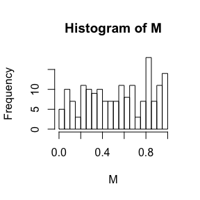

```r
my.chisq.test <- function(A)
{
  x <- na.omit(t(A))
  if (nrow(x) > 1) {
    chi2 <- chisq.test(x)
    chi2$p.value
  } else NA
}
M <- apply(MG_2019_counts, c(1, 3), my.chisq.test)
hist(M, 20)
```

Under the null hypotheses that the distributions are the same, the 176 different p-values are independent and uniformly distributed on $[0,1]$. The histogram shows the realized p-values. The number of rejections at the five percent level is given by the height of the first histogram bar. Five rejections out of 176 is less than the 8.8 we would expect, on average, under the null.

## Random Choice Structures

To make sense of most of the functions in this package, we need to introduce the concept of a Random Choice Structure (RCS), which organizes choice probabilities.

Let $T = (x_1,\ldots,x_n)$ be a universe of choice objects. When faced with a non-empty choice set $A \subseteq T$, a decision maker (DM) chooses a single object from $A$. The probability that the DM chooses $x \in A$ is denoted $P_A(x)$. A *Random Choice Structure* (RCS) is the complete specification of the $P_A(x)$, $x \in A \subseteq T$, and is denoted $P$.

The function `proportions` computes choice proportions from choice counts. The following code computes and displays the choice proportions that correspond to the cross section `N_bce` of counts constructed above. These choice proportions are an example of a RCS for the choice universe $\{b,c,e\}$.

```r
P_bce <- proportions(N_bce)  # Compute proportions from count data
print(P_bce, na.print='-')   # and display.
        Object
  Subset         b     c         e
     b   1.0000000     -         -
     c           - 1.000         -
     bc  0.9000000 0.100         -
     e           -     - 1.0000000
     be  0.5853659     - 0.4146341
     ce          - 0.075 0.9250000
     bce 0.2500000 0.025 0.7250000
```

Note that we are using the convention that for singleton sets, the choice proportions for the only element of the set are equal to 1, even if the set is never presented. This convention makes it easier to check various choice axioms, by avoiding the need for special cases.

A big part of this package is a collection of tools for plotting binary and ternary probabilities in barycentric coordinate systems. The Wikipedia page on [ternary plots](https://en.wikipedia.org/wiki/Ternary_plot) gives a nice overview of plotting ternary probabilities or proportions in the regular 2-simplex, an equililateral triangle. The page on [Barycentric coordinate systems](https://en.wikipedia.org/wiki/Barycentric_coordinate_system) gives more detail and generality.

The following code creates a figure displaying four points in barycentric coordinates, correponding to the three binary choice probability vectors and the ternary choice probability vector of the RCS `P_bce` we just constructed.

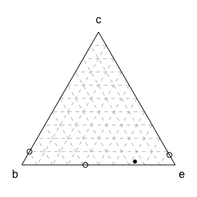

```r
triplot(label=c('b', 'c', 'e')) # Set up ternary plot, with labels and grid
plot_P3(P_bce)                  # Plot points
```

Each point in the triangle $bce$ is a unique convex combination $\lambda_b b + \lambda_c c + \lambda_e e$ of the vertices $b$, $c$ and $e$, and the vector $(\lambda_b, \lambda_c, \lambda_e)$ gives the coordinates of that point in Barycentric coordinates. Thus, the vertices $b$, $c$ and $e$ have Barycentric coordinates $(1,0,0)$, $(0,1,0)$ and $(0,0,1)$, respectively. We will interpret a point $(\lambda_b, \lambda_c, \lambda_e)$ as giving choice probabilities of $b$, $c$ and $e$ when the choice set $\{b,c,e\}$ is presented. Since triangle $bce$ is equilateral, the distances of point $(\lambda_b, \lambda_c, \lambda_e)$ to the sides $ce$, $be$ and $bc$ of the triangle are fractions $\lambda_b$, $\lambda_c$ and $\lambda_e$, respectively, of the height of the triangle.

Each of the rows 3, 5, 6 and 7 in the table above is represented by a point in the figure above. The hollow dot on the left side of the triangle gives the choice probabilities $p(b, c) = 0.9$ and $p(c, b) = 1 - p(b, c) = 0.1$. It is the convex combination $p(b, c) b + p(c, b) c$ of vertices $b$ and $c$; it is also the point $(p(b, c), p(c, b),0)$ in three dimensional barycentric coordinates. Similarly, the hollow point on the right side gives the choice probabilities $p(c, e)$ and $p(e, c)$; the hollow point on the base gives $p(b, e)$ and $p(e, b)$.

The ternary probability vector $P_{\{b,c,e\}}(\cdot)$ given in the final row of the table is indicated by a solid dot in the interior of the triangle. This point has Barycentric coordinates $(P_{\{b,c,e\}}(b), P_{\{b,c,e\}}(c), P_{\{b,c,e\}}(e)) = (0.25, 0.025, 0.725)$. We adopt the convention that binary probabilities are indicated by hollow dots and ternary probability vectors by solid dots. In this way, we can tell the difference between a binary probability and a ternary probability vector that happens to be on the boundary of the triangle.